# Regresión Lineal Simple

# 4 Precisión del modelo

Habitualmente se utilizan dos varialbes:

## 4.1 Residual Standard Error (RSE)

Se define como

$RSE = \sqrt{ \frac{\sum _{i=1}^n (y_i - \hat y)^2}{n-2} } = \sqrt{ \frac{RSS}{n-2} }$

Si recordamos, RSE es una estimación de $\sigma$. Como

$y_i = \beta_0 + \beta_1 x_i + u_i, \ u_i \sim N(0,\sigma^2)$

cuanto mayor sea $\sigma$, mayor es la variabilidad de los datos con respecto a la recta.

```r
# RSE
m3_sm = summary(m3) # consultar str(m3)
m3_sm$sigma
```

```
## [1] 3.258656
```

## 4.2 $R^2$

El problema de RSE es que depende de las unidades de los datos.

Se puede demostrar que

$\sum _{i=1}^n (y_i - \bar y)^2 = \sum _{i=1}^n (\hat y_i - \bar y)^2 + \sum _{i=1}^n (y_i - \hat y_i)^2$

Se define:

$R^2 = \frac{VE}{VT} = \frac{VT-VNE}{VT} = 1-\frac{VNE}{VT}$

- $R^2 \approx 0$. Los datos se alejan de la recta.
- $R^2 \approx 1$. Los datos se acercan a la recta.

```r
m3_sm$r.squared
```

```
## [1] 0.6118751
```

# 5 Predicción

## 5.1 Cálculo de la predicción

Para un valor $x_p$, el valor **medio** predicho por el modelo es (Predicción puntual):

$\hat m_p = \hat \beta_0 + \hat \beta_1 x_p$

Se puede demostrar que:

$\hat m_p \sim N \left( m_p, \sigma^2v_{pp} \right)$

$m_p = \beta_0 + \beta_1 x_p$

$v_{pp} = \frac{1}{n}\left(1 + \frac{(x_p - \bar x)^2}{s_x^2} \right)$

Por tanto, el **Intervalo de Confianza** es:

$m_p \in \hat m_p \pm t_{n-2;\alpha/2}*RSE*\sqrt{v_{pp}}$

```r
source("02_funciones.R")
yp = rls_pred(m1,90,0.05)
c(yp$mpp,yp$mpp1,yp$mpp2)
```

```
## [1] 11.31089 10.76492 11.85686
```

En R:

```r
xp = data.frame(x=90)
predict(m2, newdata = xp, level = 0.95, interval="confidence")
```

```
##        fit      lwr      upr
## 1 11.31089 10.76492 11.85686
```

```r
xp = data.frame(TV = 90)
predict(m3, newdata = xp, level = 0.95, interval="confidence")
```

```
##        fit      lwr      upr
## 1 11.31089 10.76492 11.85686
```

Predecimos todos los datos

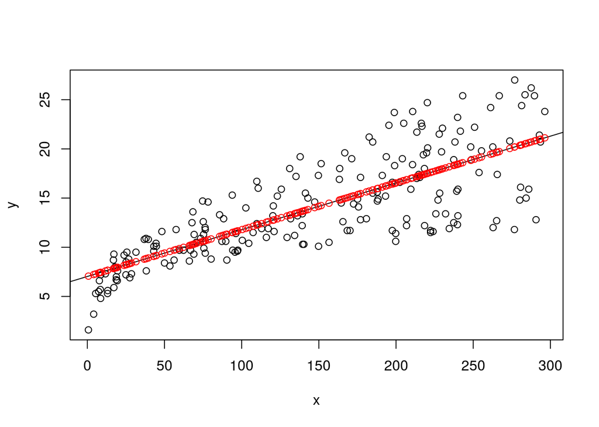

```r
pred1 = rls_pred(m1,x,0.05)
plot(x,y)
abline(a=m1$beta0_e, b=m1$beta1_e)
points(x,pred1$mpp, col = "red")
```

También se puede calcular un intervalo para la predicción de nuevos valores de la variable *y*, lo que se conoce como *intervalo de predicción*:

$y_p = \beta_0 + \beta_1 x_p + u_p = m_p + u_p \Rightarrow$

$Var(y_p) = Var(m_p) + Var(u_p) = \sigma^2 + \sigma^2v_{pp} = \sigma^2(1 + v_{pp})$

Por tanto, el **Intervalo de Predicción** es:

$\hat y_p \in \hat m_p \pm t_{n-2;\alpha/2}*RSE*\sqrt{1+v_{pp}}$

```r
c(yp$mpp,yp$ypp1,yp$ypp2)
```

```
## [1] 11.310891  4.861613 17.760170
```

En R:

```r
xp = data.frame(x=90)
predict(m2, newdata = xp, level = 0.95, interval="prediction")
```

```
##        fit      lwr      upr
## 1 11.31089 4.861613 17.76017
```

## 5.2 Precisión de la estimación

Se calcula el *mean squared error*:

$MSE = \frac{1}{n} \sum \limits _{i=1}^n (y_i - \hat y_i)^2$

Esta es una fórmula general, aplicable a todos los modelos. En el caso de regresión simple MSE es similar a RSE$^2$.

```r
yp = predict(m3, newdata = datos)
n = nrow(datos)
(MSE = 1/n*sum((y-yp)^2))
```

```
## [1] 10.51265
```

# 6 Diagnosis

El modelo de regresión simple se basa en las siguientes hipótesis:

- Normalidad: $u \sim Normal \Rightarrow y_i \sim Normal$
- Varianza de los datos constante (homocedasticidad): $Var(y_i) = \sigma^2$
- Linealidad: $E(y_i) = \beta_0 + \beta_1 x_i$

Estas hipótesis se comprueban analizando los residuos:

$e_i = y_i - (\beta_0 + \beta_1 x_i)$

Los residuos en R se calculan con la función *residuals*. Por ejemplo, el gráfico *valores predichos - residuos*:

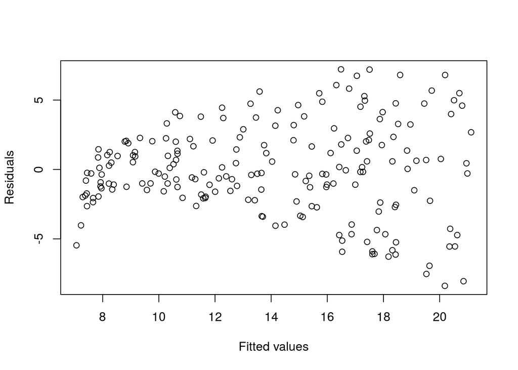

```r
plot(yp,residuals(m3), xlab = "Fitted values", ylab = "Residuals")
```

Este gráfico, junto con otros adicionales, se puede obtener con:

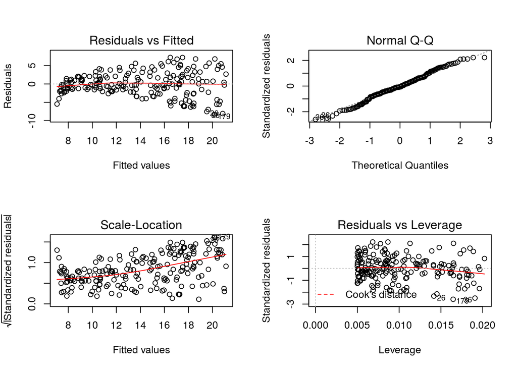

```r
par(mfrow=c(2,2))
plot(m2)
```

En este caso no se cumple homocedasticidad. Lo que se hace es utilizar una transformación cóncava de la variable *y* (generalmente log(y) $\sqrt{y}$) :

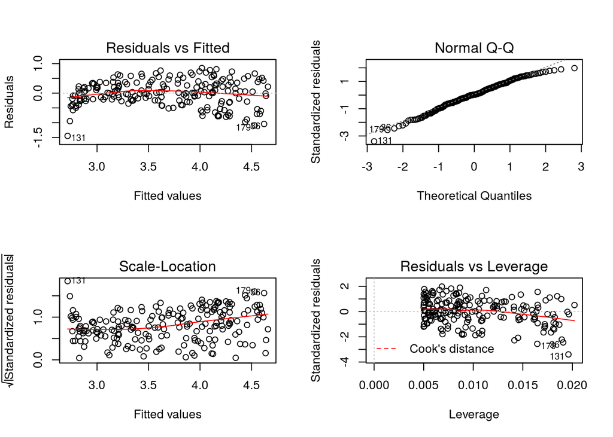

```r
m4 = lm(sqrt(sales) ~ TV, data = datos)
par(mfrow=c(2,2))
plot(m4)
```

Parece que la raiz cuadrada mejora la hipótesis de homocedasticidad. En cuanto a la bondad del nuevo modelo, apenas cambia

```r
summary(m4)
```

```
##
## Call:
## lm(formula = sqrt(sales) ~ TV, data = datos)
##
## Residuals:
##      Min       1Q   Median       3Q      Max
## -1.44955 -0.25244  0.01172  0.31823  0.85003
##
## Coefficients:
##              Estimate Std. Error t value Pr(>|t|)
## (Intercept) 2.7098601  0.0605679   44.74   <2e-16 ***
## TV          0.0065781  0.0003559   18.48   <2e-16 ***
## ---
## Signif. codes:  0 '***' 0.001 '**' 0.01 '*' 0.05 '.' 0.1 ' ' 1
##
## Residual standard error: 0.4311 on 198 degrees of freedom
## Multiple R-squared:  0.633,  Adjusted R-squared:  0.6312
## F-statistic: 341.5 on 1 and 198 DF,  p-value: < 2.2e-16
```

Igual que el MSE de las predicciones.

```r
yp_raiz = predict(m4, newdata = datos)
n = nrow(datos)
(MSE = 1/n*sum((y-(yp_raiz)^2)^2))
```

```
## [1] 10.87166
```